# R使用HBase

## 前言

目前数据科学与商业智能领域有三点不容忽视的趋势：一是集群化，随着数据量不断增长，越来越多的分析工作需要依赖于Hadoop、Spark等集群进行；二是Web化，随着数据科学工作人员整体素质的不断提高，对于分析实验的可重复性、可分享性越来越看中，很多数据分析师已经转变工作方式，开始基于Markdown记录实验文档，并将成果转化为Web分享给大家，典型例子有rmarkdown、shiny、jupyter notebook等；三是NoSQL化，传统数据库在海量数据前越来越吃力，集群的块存储模型读取过慢，NoSQL对于需要频繁交互与跟踪的数据分析任务变得很重要。

本文将要介绍的HBase依赖于Hadoop集群，是NoSQL中的典范。R语言通过Revolution Analytics提供的`rhbase`包可以方便地和HBase进行交互，再结合`shiny`可以快速地搭建一个数据分析的可视化工具。本文使用的例子对上面提到的三点趋势提供了很好的佐证。

## 环境准备

首先，按照[官方教程](https://hbase.apache.org/book.html#quickstart)安装配置HBase。

然后，按照[这篇文章](http://thrift.apache.org/docs/install/centos)安装Thrift。注意需要安装C++的Library，因为rhbase依赖于它，建议安装Thrift 0.8.0版本。

启动HBase的Thrift服务：`bin/hbase-daemon.sh start thrift`。

按照RHadoop[官方教程](https://github.com/RevolutionAnalytics/RHadoop/wiki)安装rhbase。

## rhbase基础

rhbase的文档案例写的很清楚，阅读一遍即可知道rhbase的使用方法。

```r
library(rhbase)
hb.init()
hb.new.table('testtable','x','y','z')
hb.describe.table('testtable')
# Not required to labels to be 'family:label', can just provide 'family'
# which is equivalent to 'family:'
hb.insert("testtable",list(list("20100101",c("x:a","x:f","y","y:w"), list("James Dewey",TRUE, 187.5,189000))))
hb.insert("testtable",list(list("20100102",c("x:a"), list("James Agnew"))))
hb.insert("testtable",list(list("20100103",c("y:a","y:w"), list("Dilbert Ashford",250000))))
hb.insert("testtable",list(list("20100104",c("x:f"), list("Henry Higs"))))


hb.get("testtable",list("20100101","20100102"))
hb.get("testtable",list("20100101","20100102"),c("y")) # columns that start with y
hb.get("testtable",list("20100101","20100102"),c("y:w"))
hb.get("testtable",list("20100101","20100102"),c("y:w","z"))


# delete
hb.delete("testtable","20100103","y:a")
hb.get("testtable","20100103")

## will not get 20100103, since no 'x'
iter <- hb.scan("testtable",startrow="20100100",colspec="x")
while( length(row <- iter$get(1))>0){
  print(row)
}
iter$close()

# scan from beginning
iter <- hb.scan("testtable",startrow="20100100",colspec=c('x','y','z'))
while( length(row <- iter$get(1))>0){
  print(row)
}
iter$close()

# scan uptil 20100103 (not including it)
iter <- hb.scan("testtable",startrow="20100100",end="20100103",colspec=c('x','y','z'))
while( length(row <- iter$get(1))>0){
  print(row)
}
iter$close()


# Insert a data frame
x <- data.frame(x=c("Winston","Jen","Jasmine"), y=runif(3),z=c(1,2,3))
rownames(x) <- c("20100105","20100106","20100107")
colnames(x) <- c("x:x", "y:y", "z:z")
hb.insert.data.frame("testtable",x)

# get data frame, note the columns have ":" appended
iter <- hb.get.data.frame("testtable",start="20100105")
iter()
# Uptil penultimate row
iter <- hb.get.data.frame("testtable",start="20100105",end="20100107")
iter()

# clean up
hb.delete.table("testtable")
```

rhbase有三种序列化的方式，一种是R的native模式，一种是raw模式（即一堆字节码），一种是character模式。如果表数据的写入和读取都只用R，建议用native模式（这也是默认模式）。如果数据读取或写入还需要别的语言，建议用raw或character。不考虑存储空间，为了方便人读取，使用character模式最方便。设置序列化的方法如下：

```r
hb.init(host="127.0.0.1", port=9090, serialize = "character")
```

## rhbase与shiny结合

本节提供一个rhbase与shiny结合的一个案例：根据道路编号与日期，查询道路某一天的24小时通车数曲线；根据道路编号与日期范围，查询道路在这段日期范围内的每日通车数。

我们首先需要建立一张HBase表，表的规格设置如下：

| 字段 | 描述 |
| --- | --- |
| `row_key` | HBase表的键，格式为道路编号_日期 |
| `link:tc` | HBase表的列，列族为`link`，列为`tc`，表示`row_key`对应的日通车数 |
| `link:tc_10m` | HBase表的列，列族为`link`，列为`tc_10m`，表示`row_key`对应的这一天这一条道路每10分钟的通车数，按照时间排序，共144个，格式为`[通车数1，通车数2，...]` |

可视化工具的代码如下：

```r
library(rhbase)
library(stringr)
library(jsonlite)
library(lubridate)
library(xts)
library(dygraphs)
library(shiny)
library(tidyr)
library(dplyr)


# init
hb.init(host="127.0.0.1", port=9090, serialize="character")
hb.list.tables()
table_name <- "test"
hb.describe.table(table_name)

ui <- fluidPage(
  titlePanel("Traffic Flow Viewer"),
  hr(),
  h3("Link flow plot per 10 min"),
  sidebarLayout(
    sidebarPanel(
      textInput(inputId = "link", label = "Link:", value="xxxx, lllll, oooo "),
      dateInput(inputId = "dt_10m", label = "Date:", value="2016-12-05"),
      width=3
    ),
    mainPanel(
      textOutput(outputId = "text_10m"),
      dygraphOutput(outputId = "plot_10m"),
      width=9
    )
  ),
  hr(),
  h3("Link flow plot per day"),
  sidebarLayout(
    sidebarPanel(
      dateRangeInput(inputId = "dt_day", label = "Date Range:", start="2016-11-26", end="2016-12-06"),
      width=3
    ),
    mainPanel(
      dygraphOutput(outputId = "plot_day"),
      width=9
    )
  )
)

server <- function(input, output, session) {
  get_link_flow <- reactive({
    row_key <- str_c(str_trim(unlist(str_split(input$link, ","))), as.character(input$dt_10m, format="%Y%m%d"), sep="_")
    return(hb.get(table_name, as.list(row_key), c('link:tc_10m')))
  })

  batch_get_link_flow <- reactive({
    links <- str_trim(unlist(str_split(input$link, ",")))
    dts <- as.character(seq(as.POSIXct(input$dt_day[1]),as.POSIXct(input$dt_day[2]), by="1 day"), format="%Y%m%d")
    row_key <- (tidyr::unite(expand.grid(link=links, dt=dts), row_key, link, dt))$row_key
    # row_key <- setNames(split(comb_df, seq(nrow(comb_df))), NULL)
    return(hb.get(table_name, as.list(row_key), c('link:tc')))
  })

  output$plot_10m <- renderDygraph({
    if(input$link != "" && !is.na(input$link)) {
      link_flow <- get_link_flow()
      if(length(link_flow[[1]][[3]]) >= 1) {
        obs_df <- NULL
        for(i in 1:length(link_flow)) {
          obs_link <- str_split(link_flow[[i]][[1]], "_")[[1]][1]
          obs_dt <- str_split(link_flow[[i]][[1]], "_")[[1]][2]
          obs_flow <- data.frame(cnt=fromJSON(link_flow[[i]][[3]][[1]]))
          colnames(obs_flow) <- c(obs_link)
          if(is.null(obs_df)) {
            obs_df <- obs_flow
          }
          else {
            obs_df <- cbind(obs_df, obs_flow)
          }
        }
        dt_point <- ymd(obs_dt, tz="Asia/Shanghai") + dseconds(1:nrow(obs_flow) * 600)
        rownames(obs_df) <- dt_point
        dygraph(as.xts(obs_df)) %>%
          dyOptions(drawPoints = TRUE, pointSize = 2)
      }
    }
  })

  output$plot_day <- renderDygraph({
    if(input$link != "" && !is.na(input$link)) {
      link_flow <- batch_get_link_flow()
      obs_df <- data.frame()
      for(i in 1:length(link_flow)) {
        if(length(link_flow[[i]][[3]]) >= 1) {
          obs_link <- str_split(link_flow[[i]][[1]], "_")[[1]][1]
          obs_dt <- ymd(str_split(link_flow[[i]][[1]], "_")[[1]][2])
          obs_flow <- as.integer(link_flow[[i]][[3]][[1]])
          obs_df <- rbind(obs_df, data.frame(link_id=obs_link, dt=obs_dt, cnt=obs_flow))
        }
      }
      obs_df <- obs_df %>% spread(link_id, cnt)
      rownames(obs_df) <- ymd(obs_df$dt)
      obs_df <- obs_df %>% select(-dt)
      dygraph(as.xts(obs_df)) %>%
        dyOptions(drawPoints = TRUE, pointSize = 2) %>%
        dyRangeSelector()
    }
  })

  output$text_10m <- renderText({
    if(input$link != "" && !is.na(input$link)) {
      link_flow <- get_link_flow()
      if(length(link_flow[[1]][[3]]) >= 1) {
        "The 10 min flow plot is below:"
      }
      else {
        "Row key could not be found"
      }
    }
    else {
      "Please specify the link"
    }
  })

}

shinyApp(ui=ui, server=server)
```

效果图如下：

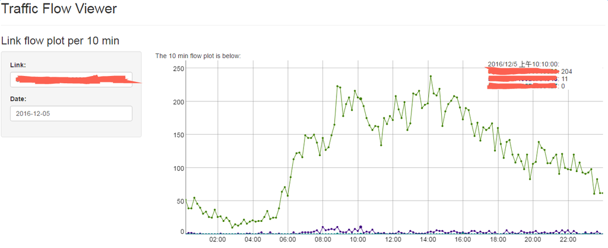

10分钟流量曲线

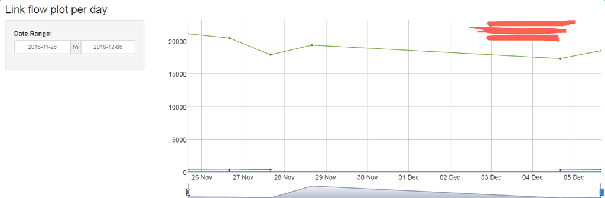

每日流量曲线

## 补充：HBase的理论知识

HDFS和MapReduce的配合赋予了廉价计算机集群处理海量数据的能力，然而这种配合尚缺乏实时随机存取的能力。HBase完善了Hadoop生态系统进行随机存取的能力。 ### HBase表 HBase与关系型数据库类似，按照表来组织数据。表由若干行组成，每个行由行键唯一确定，行键按照字典序排序。一行由若干列族组成，每个列族下面又含若干列。相同列族的列存储在同一个底层的文件HFile里。每一列的值具有时间戳，用于保存不同的版本。综上，HBase的表结构可以表示为：{Table, RowKey, Family, Column, Timestamp} -> Value. HBase的可扩展性体现在region，region本质上是以行键排序的连续存储空间。

HBase不支持SQL，只支持API模式，提供了建表、删表、增加列族和删除列族操作，并能对表和列族进行修改。客户端还可以通过API对给定的键值进行增加、删除和查找。另外，scan API提供了高效遍历某个范围的行的功能。通过设置过滤器可以匹配返回的列，通过设置起始和终止的时间范围可以选择查询版本。

### 实现原理

HBase的数据存储在store file中，即HFile。每个HFile内的键值都是排序的。HFile内部由连续的块组成。store file通常保存在HDFS上，以利用HDFS的冗余功能，保证数据不丢失。

更新数据时，会先将数据记录在提交日志中，称为预写日志（Write-ahead log，WAL），然后将这些数据写入内存中的memstore中。当数据超过了memstore的阈值，系统会将数据移出内存持久化到磁盘中生成HFile。相对应的提交日志在持久化后会被丢弃。memstore中的数据已经在内存中按照行健进行排序，所以持久化时只需要按照顺序写就行。 删除数据时，因为 store file不能改变，所以只对该行做个删除标记。

检索数据时，首先查找memstore中还没有写入磁盘的数据，没找到的话再查找磁盘上的HFile。

当HFile数量越来越多时，HBase会启动进程将多个文件合并为一个较大的文件。合并分两种，第一种minor compaction，就是进行多路归并，第二种major compaction，将一个region中一个列族的若干个HFile重写为一个新HFile，即扫描所有的键值对，顺序重写全部的数据，重写数据的过程中忽略做了删除标记的数据。

上述过程的理论被称为LSM树，和B+树的对比请参考[这篇文章](http://www.oschina.net/question/565065_113615)

### ZooKeeper在HBase中的作用

ZooKeeper的功能总结起来是文件系统+通知机制。在HBase中，ZooKeeper大致有三个作用。首先会存储-ROOT-表，里面包含了主节点HMaster的地址。然后，RegionServer会在ZooKeeper指定路径下创建临时节点，HMaster通过监控临时节点感知RegionServer的状态。最后，HMaster的选举也会通过ZooKeeper进行。

### 应用场景

#### 快速查找

假设现在要查找一个指定行健指定列族的某个列值。为了实现这个目标，关键是要在大量的数据中定位出行键的位置。假设我们有10亿条记录，一共1TB的存储量。

首先，HBase会查找到包含该行键的region。如果有500个region，那么我们实际要读取的磁盘数据量只剩下1TB/500=2GB。

其次，HBase是按列族存储的。假设表中共有3个列族，每个列族的数据量平均是2GB/3=666M。我们要查询的只是其中一个列族，因此只需要扫描666M。一个列族包含一个或多个HStoreFile，我们要查找的行键可能在HStoreFile的开始、中间、末尾，平均下来我们按顺序扫描需要扫300M。

最后，每个HStoreFile存储的是key-value，我们只需要遍历key，不需要遍历value。假设key和value的大小为1:19，那么我们只需要扫描15M就能获得对应记录。磁盘访问速度约为100M/s，只需要0.15s。

#### 实时查询

由于LSM树架构的特点，最新的数据都保存在内存中。所以实时的数据通过内存即可获得，因此响应速度很快。

Copyright © 2016 陈水平. All rights reserved.